© Bản quyền thuộc về Quantopian Inc.  
© Bản quyền sửa đổi thuộc về AI Cafe¹  
Giấy phép [Creative Commons Attribution 4.0](https://creativecommons.org/licenses/by/4.0/legalcode).  
[Khuyến cáo](https://aicafe.one/khuyen-cao/)

# Giới thiệu về giao dịch cặp (Pairs Trading)

By Delaney Mackenzie and Maxwell Margenot

Edited by AI Cafe¹

Giao dịch cặp là một ví dụ cổ điển về một chiến lược dựa trên phân tích toán học. Nguyên tắc như sau. Giả sử bạn có một cặp chứng khoán X và Y có một mối liên hệ kinh tế cơ bản nào đó. Một ví dụ có thể là hai công ty sản xuất cùng một sản phẩm, hoặc hai công ty trong cùng một chuỗi cung ứng. Nếu chúng ta có thể mô hình hóa mối liên hệ kinh tế này bằng một mô hình toán học, chúng ta có thể thực hiện các giao dịch dựa trên nó. Chúng ta sẽ bắt đầu bằng cách xây dựng một ví dụ đơn giản.

Trước khi tiến hành, hãy lưu ý rằng nội dung trong bài giảng này phụ thuộc rất nhiều vào bài giảng về Tích hợp, Đồng tích hợp và Tính dừng để có thể hiểu đúng cơ sở toán học cho phương pháp mà chúng ta áp dụng ở đây. Vì vậy, bạn nên xem qua bài giảng đó trước khi tiếp tục với bài giảng này.

```python
import numpy as np
import pandas as pd

import statsmodels.api as sm
from statsmodels.tsa.stattools import coint
# just set the seed for the random number generator
np.random.seed(107)

import matplotlib.pyplot as plt
```

## Tạo ra Hai Chứng Khoán Giả

Chúng ta mô hình hóa lợi nhuận hàng ngày của X bằng cách lấy mẫu từ một phân phối chuẩn. Sau đó, chúng ta thực hiện tổng hợp tích lũy để có giá trị của X vào mỗi ngày.

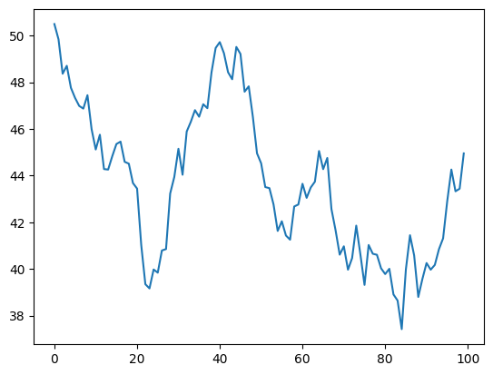

```python
X_returns = np.random.normal(0, 1, 100) # Generate the daily returns
# sum them and shift all the prices up into a reasonable range
X = pd.Series(np.cumsum(X_returns), name='X') + 50
X.plot();
```

Bây giờ chúng ta sẽ tạo ra Y. Hãy nhớ rằng Y có mối liên hệ kinh tế sâu sắc với X, vì vậy giá của Y nên biến động tương tự như X. Chúng ta mô phỏng điều này bằng cách lấy X, dịch chuyển nó lên và thêm một số nhiễu ngẫu nhiên được rút ra từ phân phối chuẩn.

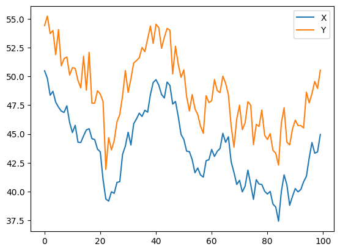

```python
some_noise = np.random.normal(0, 1, 100)
Y = X + 5 + some_noise
Y.name = 'Y'
pd.concat([X, Y], axis=1).plot();
```

## Đồng tích hợp (Cointegration)

Chúng tôi đã xây dựng một ví dụ về hai chuỗi đồng tích hợp. Đồng tích hợp là một mối quan hệ tinh vi hơn so với tương quan. Nếu hai chuỗi thời gian đồng tích hợp, thì có một số tổ hợp tuyến tính giữa chúng sẽ biến động xung quanh một giá trị trung bình. Ở mọi thời điểm, tổ hợp giữa chúng liên quan đến cùng một phân phối xác suất.

Để biết thêm chi tiết về cách chúng tôi định nghĩa chính thức đồng tích hợp và cách hiểu nó, xin vui lòng tham khảo bài giảng về Tích hợp, Đồng tích hợp và Tính ổn định.

Bây giờ chúng ta sẽ vẽ đồ thị sự chênh lệch giữa hai chuỗi để có thể thấy nó trông như thế nào.

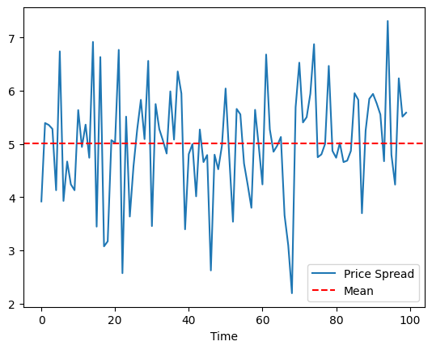

```python
(Y - X).plot() # Plot the spread
plt.axhline((Y - X).mean(), color='red', linestyle='--') # Add the mean
plt.xlabel('Time')
plt.legend(['Price Spread', 'Mean']);
```

## Kiểm tra Đồng tích hợp

Đó là một định nghĩa trực quan, nhưng làm thế nào chúng ta có thể kiểm tra điều này một cách thống kê? Có một bài kiểm tra đồng tích hợp thuận tiện có sẵn trong `statsmodels.tsa.stattools`. Giả sử mức độ tin cậy của chúng ta là $0.05$. Chúng ta nên thấy giá trị p dưới ngưỡng của chúng ta, vì chúng ta đã tạo ra một cách nhân tạo hai chuỗi mà là định nghĩa điển hình của đồng tích hợp.

```python
# compute the p-value of the cointegration test
# will inform us as to whether the spread between the 2 timeseries is stationary
# around its mean
score, pvalue, _ = coint(X,Y, maxlag=1)
print(pvalue)
```

```
2.0503418653415035e-16
```

### Tương quan và Đồng tích hợp

Tương quan và đồng tích hợp, mặc dù về lý thuyết có vẻ tương tự, nhưng không phải là cùng một khái niệm. Để chứng minh điều này, chúng ta sẽ đưa ra các ví dụ về các chuỗi có tương quan nhưng không đồng tích hợp, và ngược lại. Để bắt đầu, hãy kiểm tra tương quan của các chuỗi mà chúng ta vừa tạo ra.

```python
X.corr(Y)
```

```
np.float64(0.9497090646385932)
```

Tương quan cao như chúng ta mong đợi. Nhưng hai chuỗi có tương quan mà không đồng tích hợp sẽ trông như thế nào?

### Tương quan mà không có Đồng tích hợp

Một ví dụ là hai chuỗi chỉ đơn giản là phân kỳ.

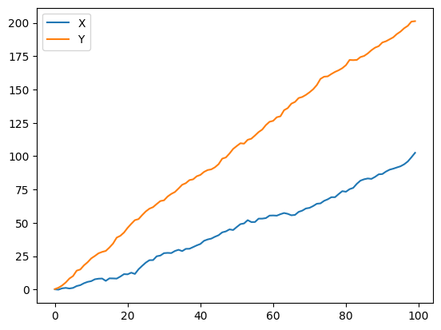

```python
X_returns = np.random.normal(1, 1, 100)
Y_returns = np.random.normal(2, 1, 100)

X_diverging = pd.Series(np.cumsum(X_returns), name='X')
Y_diverging = pd.Series(np.cumsum(Y_returns), name='Y')

pd.concat([X_diverging, Y_diverging], axis=1).plot();
```

```python
print('Correlation: ' + str(X_diverging.corr(Y_diverging)))
score, pvalue, _ = coint(X_diverging,Y_diverging, maxlag=1)
print('Cointegration test p-value: ' + str(pvalue))
```

```
Correlation: 0.9931343801275687
Cointegration test p-value: 0.8815557674695222
```

### Đồng tích hợp mà không có Tương quan

Một ví dụ đơn giản cho trường hợp này là một chuỗi phân phối chuẩn và một sóng vuông.

```python
Y2 = pd.Series(np.random.normal(0, 1, 1000), name='Y2') + 20
Y3 = Y2.copy()
```

```python
# Y2 = Y2 + 10
Y3[0:100] = 30
Y3[100:200] = 10
Y3[200:300] = 30
Y3[300:400] = 10
Y3[400:500] = 30
Y3[500:600] = 10
Y3[600:700] = 30
Y3[700:800] = 10
Y3[800:900] = 30
Y3[900:1000] = 10
```

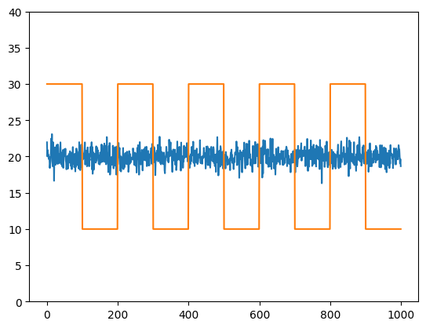

```python
Y2.plot()
Y3.plot()
plt.ylim([0, 40]);
```

```python
# correlation is nearly zero
print('Correlation: ' + str(Y2.corr(Y3)))
score, pvalue, _ = coint(Y2,Y3, maxlag=1)
print('Cointegration test p-value: ' + str(pvalue))
```

```
Correlation: -0.04130406958091664
Cointegration test p-value: 0.0
```

Chắc chắn rồi, tương quan là rất thấp, nhưng giá trị p cho thấy rằng chúng có đồng tích hợp.

## Phòng Vệ

Bởi vì bạn muốn bảo vệ mình khỏi những thị trường xấu, thường thì việc bán khống sẽ được sử dụng để phòng vệ cho các khoản đầu tư dài hạn. Vì một giao dịch bán khống sẽ kiếm lời nếu chứng khoán bán ra mất giá, và một giao dịch mua dài hạn sẽ kiếm lời nếu chứng khoán tăng giá, bạn có thể đầu tư dài hạn vào một số phần của thị trường và bán khống vào những phần khác. Bằng cách đó, nếu toàn bộ thị trường giảm mạnh, chúng ta vẫn sẽ kiếm được tiền từ các chứng khoán đã bán khống và hy vọng có thể hòa vốn. Trong trường hợp của hai chứng khoán, chúng ta sẽ gọi đây là một vị trí phòng vệ khi chúng ta nắm giữ một chứng khoán dài hạn và bán khống chứng khoán còn lại.

## Mẹo: Nơi mọi thứ kết hợp lại

Bởi vì các chứng khoán có xu hướng tiến gần và xa nhau, sẽ có những lúc khoảng cách giữa chúng lớn và những lúc khoảng cách nhỏ. Mẹo của giao dịch cặp đến từ việc duy trì một vị trí phòng vệ giữa X và Y. Nếu cả hai chứng khoán đều giảm, chúng ta sẽ không kiếm được hay mất tiền, và tương tự nếu cả hai đều tăng. Chúng ta kiếm tiền từ sự chênh lệch của hai chứng khoán quay về trung bình. Để làm điều này, chúng ta sẽ theo dõi khi X và Y cách xa nhau, sau đó bán khống Y và mua dài hạn X. Tương tự, chúng ta sẽ theo dõi khi chúng gần nhau, và mua dài hạn Y và bán khống X.

### Mua Dài Hạn Chênh Lệch

Đây là khi chênh lệch nhỏ và chúng ta kỳ vọng nó sẽ lớn hơn. Chúng ta đặt cược vào điều này bằng cách mua dài hạn Y và bán khống X.

### Bán Khống Chênh Lệch

Đây là khi chênh lệch lớn và chúng ta kỳ vọng nó sẽ nhỏ hơn. Chúng ta đặt cược vào điều này bằng cách bán khống Y và mua dài hạn X.

### Cược Cụ Thể

Một khái niệm quan trọng ở đây là chúng ta đang đặt cược vào một điều cụ thể, và cố gắng giảm sự phụ thuộc của cược đó vào các yếu tố khác như thị trường.

## Tìm các chứng khoán thực sự có hành vi như vậy

Cách tốt nhất để làm điều này là bắt đầu với những chứng khoán mà bạn nghi ngờ có thể đồng tích hợp và thực hiện một bài kiểm tra thống kê. Nếu bạn chỉ thực hiện các bài kiểm tra thống kê trên tất cả các cặp, bạn sẽ dễ rơi vào thiên kiến so sánh nhiều.

Dưới đây là một phương pháp để xem qua danh sách các chứng khoán và kiểm tra sự đồng tích hợp giữa tất cả các cặp. Nó trả về một ma trận điểm kiểm tra đồng tích hợp, một ma trận p-value, và bất kỳ cặp nào mà p-value nhỏ hơn $0.05$.

### CẢNH BÁO: Điều này sẽ gây ra một lượng lớn thiên lệch so sánh nhiều.

Các phương pháp tìm cặp khả thi đều nằm trên một phổ. Ở một đầu là việc hình thành một giả thuyết kinh tế cho một cặp cá nhân. Bạn có một số kiến thức bổ sung về một mối liên kết kinh tế khiến bạn tin rằng cặp này là đồng tích hợp, vì vậy bạn đi ra ngoài và kiểm tra sự tồn tại của đồng tích hợp. Trong trường hợp này, bạn sẽ không gặp phải thiên lệch so sánh nhiều. Ở đầu kia của phổ, bạn thực hiện một cuộc tìm kiếm qua hàng trăm chứng khoán khác nhau để tìm bất kỳ cặp khả thi nào theo bài kiểm tra của bạn. Trong trường hợp này, bạn sẽ gặp phải một lượng lớn thiên lệch so sánh nhiều.

Thiên lệch so sánh nhiều là khả năng tăng lên để tạo ra một p-value có ý nghĩa không chính xác khi nhiều bài kiểm tra được thực hiện. Nếu 100 bài kiểm tra được thực hiện trên dữ liệu ngẫu nhiên, chúng ta nên mong đợi thấy 5 p-value dưới $0.05$ theo kỳ vọng. Bởi vì chúng ta sẽ thực hiện $n(n-1)/2$ so sánh, chúng ta nên mong đợi thấy nhiều p-value có ý nghĩa sai. Để phục vụ cho ví dụ này, chúng ta sẽ bỏ qua điều này và tiếp tục. Trong thực tế, một bước xác minh thứ hai sẽ cần thiết nếu tìm kiếm cặp theo cách này. Một cách tiếp cận khác là chọn một số cặp nhỏ mà bạn có lý do nghi ngờ rằng có thể là đồng tích hợp và kiểm tra từng cặp một. Điều này sẽ dẫn đến ít tiếp xúc hơn với thiên lệch so sánh nhiều. Bạn có thể đọc thêm về thiên lệch so sánh nhiều [tại đây](https://en.wikipedia.org/wiki/Multiple_comparisons_problem).

```python
def find_cointegrated_pairs(data):
    n = data.shape[1]
    score_matrix = np.zeros((n, n))
    pvalue_matrix = np.ones((n, n))
    keys = data.keys()
    pairs = []
    for i in range(n):
        for j in range(i+1, n):
            S1 = data[keys[i]]
            S2 = data[keys[j]]
            result = coint(S1, S2, maxlag=1)
            score = result[0]
            pvalue = result[1]
            score_matrix[i, j] = score
            pvalue_matrix[i, j] = pvalue
            if pvalue < 0.05:
                pairs.append((keys[i], keys[j]))
    return score_matrix, pvalue_matrix, pairs
```

## Tìm kiếm các cặp chứng khoán bất động sản đồng tích hợp

Chúng tôi đang xem xét một tập hợp các cổ phiếu công ty bất động sản để xem có cổ phiếu nào trong số đó là đồng tích hợp hay không. Chúng tôi sẽ bắt đầu bằng cách xác định danh sách các chứng khoán mà chúng tôi muốn xem xét. Sau đó, chúng tôi sẽ lấy dữ liệu giá cho từng chứng khoán trong năm 2024.

Cách tiếp cận của chúng tôi nằm ở giữa phổ mà chúng tôi đã đề cập trước đó. Chúng tôi đã hình thành một giả thuyết kinh tế rằng có một mối liên hệ nào đó giữa một tập hợp con các chứng khoán trong lĩnh vực bất động sản và chúng tôi muốn kiểm tra xem có cặp nào đồng tích hợp hay không. Điều này gây ra ít thiên lệch so với việc so sánh nhiều hơn việc tìm kiếm hàng trăm chứng khoán và hơi nhiều hơn việc hình thành một giả thuyết cho một bài kiểm tra cá nhân.

LƯU Ý: Chúng tôi bao gồm thị trường trong dữ liệu của mình. Điều này là vì thị trường thúc đẩy sự biến động của rất nhiều chứng khoán, do đó bạn thường có thể tìm thấy hai chứng khoán có vẻ như đồng tích hợp, nhưng trên thực tế chúng không đồng tích hợp và chỉ đồng tích hợp với thị trường. Đây được gọi là biến nhiễu và rất quan trọng để kiểm tra sự tham gia của thị trường trong bất kỳ mối quan hệ nào mà bạn tìm thấy.

```python
# Cài thư viện lấy dữ liệu miễn phí
!curl -fsSLO https://raw.githubusercontent.com/algo-stocks/data/master/data.py
```

```python
from data import get_prices

start = '2024-01-01'
end = '2025-01-01'

prices_df = get_prices('VHM', 'VIC', 'VRE', 'HDG', 'VNINDEX', start_date=start, end_date=end).ffill()
```

Bây giờ chúng ta sẽ chạy phương pháp của mình trên danh sách và xem có cặp nào là đồng tích hợp hay không.

```
[('VIC', 'VRE')]
```

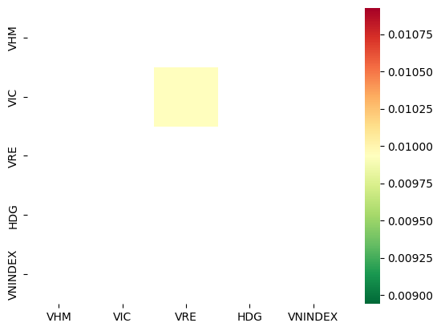

```python
# Heatmap to show the p-values of the cointegration test between each pair of
# stocks. Only show the value in the upper-diagonal of the heatmap
scores, pvalues, pairs = find_cointegrated_pairs(prices_df)
import seaborn
seaborn.heatmap(
    pvalues,
    xticklabels=prices_df.columns,
    yticklabels=prices_df.columns,
    cmap='RdYlGn_r',
    mask = (pvalues >= 0.05))
print(pairs)
```

Có vẻ như 'VIC' và 'VRE' có sự đồng tích hợp. Hãy xem xét giá cả để đảm bảo rằng không có điều gì kỳ lạ xảy ra.

```python
S1 = prices_df['VIC']
S2 = prices_df['VRE']
```

```python
score, pvalue, _ = coint(S1, S2, maxlag=1)
pvalue
```

```
np.float64(0.009933718110850642)
```

## Tính Toán Chênh Lệch

Bây giờ chúng ta sẽ vẽ chênh lệch của hai chuỗi. Để thực sự tính toán chênh lệch, chúng ta sử dụng hồi quy tuyến tính để lấy hệ số cho tổ hợp tuyến tính giữa hai tài sản của chúng ta, như đã trình bày trong bài giảng về Tích hợp, Đồng tích hợp và Độ ổn định. Việc sử dụng hồi quy tuyến tính để ước lượng hệ số được gọi là phương pháp Engle-Granger.

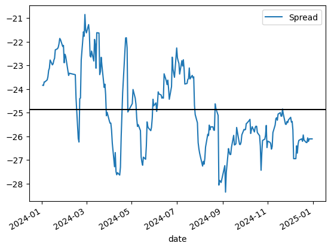

```python
S1 = sm.add_constant(S1)
results = sm.OLS(S2, S1).fit()
S1 = S1['VIC']
b = results.params['VIC']

spread = S2 - b * S1
spread.plot()
plt.axhline(spread.mean(), color='black')
plt.legend(['Spread']);
```

Ngoài ra, chúng ta có thể xem xét tỷ lệ giữa hai chuỗi.

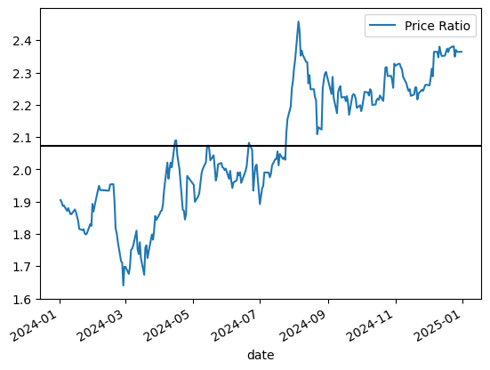

```python
ratio = S1/S2
ratio.plot()
plt.axhline(ratio.mean(), color='black')
plt.legend(['Price Ratio']);
```

Việc xem xét tỷ lệ giá của một cặp giao dịch là một cách truyền thống để xử lý giao dịch cặp. Một phần lý do tại sao điều này hoạt động như một tín hiệu dựa trên các giả định của chúng ta về cách mà giá cổ phiếu di chuyển, cụ thể là vì giá cổ phiếu thường được giả định phân phối theo log-normal. Điều này có nghĩa là khi lấy tỷ lệ của các giá, chúng ta đang thực hiện một tổ hợp tuyến tính của các lợi suất liên quan (vì giá chỉ là các lợi suất được lấy lũy thừa).

Điều này có thể gây khó chịu cho mục đích của chúng ta vì việc mua đúng tỷ lệ của một cặp giao dịch có thể không thực tiễn. Thay vào đó, chúng tôi chọn tiếp tục với việc tính toán chênh lệch giữa các cổ phiếu đồng tích hợp bằng cách sử dụng hồi quy tuyến tính. Đây là một cách rất đơn giản để xử lý mối quan hệ, tuy nhiên, có thể không khả thi cho các ví dụ không đơn giản. Có những phương pháp tiềm năng khác để ước lượng chênh lệch được liệt kê ở cuối bài giảng này. Nếu bạn muốn tìm hiểu sâu hơn về lý thuyết tại sao việc có các cổ phiếu đồng tích hợp quan trọng cho giao dịch cặp, một lần nữa, hãy xem bài giảng về Tích hợp, Đồng tích hợp và Độ ổn định.

Vậy, quay lại với ví dụ của chúng ta. Chênh lệch tuyệt đối không thực sự hữu ích về mặt thống kê. Thay vào đó, việc chuẩn hóa tín hiệu của chúng ta bằng cách coi nó như một z-score sẽ giúp ích hơn.

### CẢNH BÁO

Trên thực tế, điều này thường được thực hiện để cố gắng tăng quy mô cho dữ liệu, nhưng điều này giả định một phân phối cơ bản nào đó, thường là phân phối chuẩn. Dưới một phân phối chuẩn, chúng ta sẽ biết rằng khoảng 84% tất cả các giá trị chênh lệch sẽ nhỏ hơn. Tuy nhiên, nhiều dữ liệu tài chính không phân phối chuẩn, và cần phải rất cẩn thận không giả định tính chuẩn, cũng như không giả định bất kỳ phân phối cụ thể nào khi tạo ra các thống kê. Có thể trường hợp phân phối thật sự của các chênh lệch là rất dày đuôi và dễ bị ảnh hưởng bởi các giá trị cực đoan. Điều này có thể làm rối loạn mô hình của chúng ta và dẫn đến những tổn thất lớn.

```python
def zscore(series):
    return (series - series.mean()) / np.std(series)
```

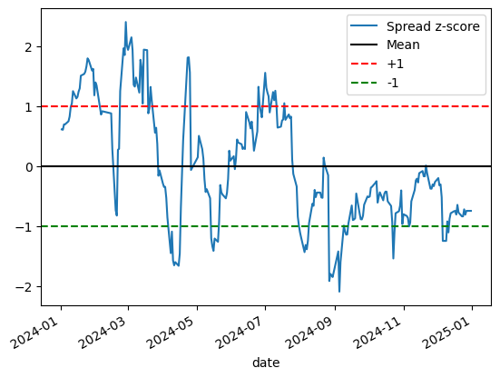

```python
zscore(spread).plot()
plt.axhline(zscore(spread).mean(), color='black')
plt.axhline(1.0, color='red', linestyle='--')
plt.axhline(-1.0, color='green', linestyle='--')
plt.legend(['Spread z-score', 'Mean', '+1', '-1']);
```

### Chiến lược đơn giản:

- Mở vị thế "Long" khi z-score dưới -1.0
- Mở vị thế "Short" khi z-score trên 1.0
- Đóng vị thế khi z-score tiến gần về 0

Đây chỉ là bề nổi của tảng băng và chỉ là một ví dụ rất đơn giản để minh họa các khái niệm. Trong thực tế, bạn sẽ muốn tính toán một cách tối ưu hơn về tỷ lệ nắm giữ bao nhiêu cổ phiếu cho S1 và S2. Một số tài liệu bổ sung về giao dịch cặp được liệt kê ở cuối bài giảng này.

## Giao dịch bằng cách sử dụng thống kê cập nhật liên tục

Nói chung, việc lấy một thống kê trên toàn bộ kích thước mẫu của bạn có thể không tốt. Ví dụ, nếu thị trường đang đi lên và cả hai chứng khoán đều đi lên theo, thì giá trung bình của bạn trong 3 năm qua có thể không đại diện cho ngày hôm nay. Vì lý do này, các nhà giao dịch thường sử dụng các thống kê dựa vào các cửa sổ động của dữ liệu gần đây nhất.

## Trung bình động

Trung bình động chỉ là một trung bình của $n$ điểm dữ liệu gần nhất cho mỗi thời điểm nhất định. Nó sẽ không xác định được cho $n$ điểm dữ liệu đầu tiên trong chuỗi của chúng ta. Trung bình động ngắn hơn sẽ dao động nhiều hơn và ít đáng tin cậy hơn, nhưng phản ứng nhanh với thông tin mới. Trung bình động dài hơn sẽ mượt mà hơn, nhưng mất nhiều thời gian hơn để tích hợp thông tin mới.

Chúng ta cũng cần sử dụng beta lăn, một ước lượng lăn về cách mà độ chênh lệch của chúng ta nên được tính toán, để giữ cho tất cả các tham số của chúng ta được cập nhật.

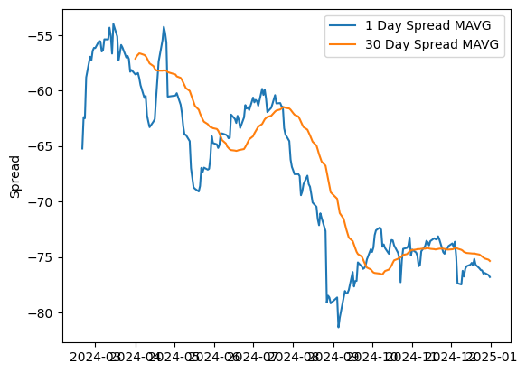

```python
# Get the spread between the 2 stocks
# Calculate rolling beta coefficient
window = 30
rolling_beta = [np.nan] * window
for n in range(window, len(S1)):
    y = S1[(n - window):n]
    X = S2[(n - window):n]
    rolling_beta.append(sm.OLS(y, X).fit().params.iloc[0])

rolling_beta = pd.Series(rolling_beta, index=S2.index)

spread = S2 - rolling_beta * S1
spread.name = 'spread'

# Get the 1 day moving average of the price spread
spread_mavg1 = spread.rolling(window=1).mean()
spread_mavg1.name = 'spread 1d mavg'

# Get the 30 day moving average
spread_mavg30 = spread.rolling(30).mean()
spread_mavg30.name = 'spread 30d mavg'

plt.plot(spread_mavg1.index, spread_mavg1.values)
plt.plot(spread_mavg30.index, spread_mavg30.values)

plt.legend(['1 Day Spread MAVG', '30 Day Spread MAVG'])

plt.ylabel('Spread');
```

Chúng ta có thể sử dụng các trung bình động để tính toán điểm z (z-score) của độ chênh lệch tại mỗi thời điểm nhất định. Điều này sẽ cho chúng ta biết độ chênh lệch là cực đoan đến mức nào và liệu có phải là một ý tưởng tốt để tham gia vào vị trí vào thời điểm này hay không. Hãy cùng xem xét điểm z ngay bây giờ.

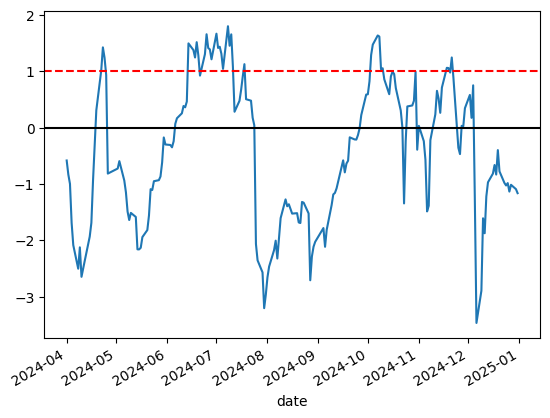

```python
# Take a rolling 30 day standard deviation
std_30 = spread.rolling(30).std()
std_30.name = 'std 30d'

# Compute the z score for each day
zscore_30_1 = (spread_mavg1 - spread_mavg30)/std_30
zscore_30_1.name = 'z-score'
zscore_30_1.plot()
plt.axhline(0, color='black')
plt.axhline(1.0, color='red', linestyle='--');
```

z-score không có nhiều ý nghĩa nếu không có bối cảnh, vì vậy hãy vẽ nó bên cạnh các mức giá để có được cái nhìn về cách mà nó trông như thế nào.

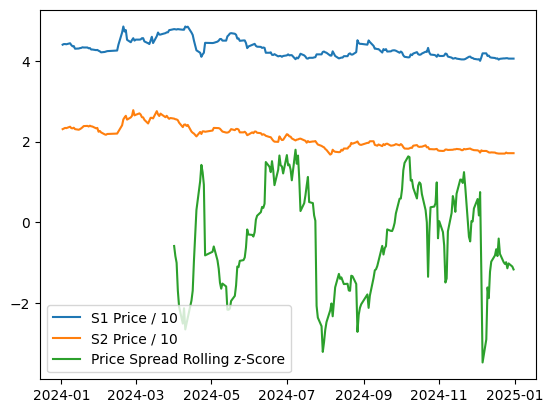

```python
# Plot the prices scaled down along with the negative z-score
# just divide the stock prices by 10 to make viewing it on the plot easier
plt.plot(S1.index, S1.values/10)
plt.plot(S2.index, S2.values/10)
plt.plot(zscore_30_1.index, zscore_30_1.values)
plt.legend(['S1 Price / 10', 'S2 Price / 10', 'Price Spread Rolling z-Score']);
```

## Kiểm tra ngoài mẫu

Bây giờ mà chúng ta đã xây dựng độ chênh lệch của mình một cách hợp lý và có ý tưởng về cách thực hiện giao dịch, đã đến lúc tiến hành một bài kiểm tra ngoài mẫu. Toàn bộ mô hình của chúng ta dựa trên giả định rằng các chứng khoán này là đồng tích hợp, nhưng chúng ta đã xây dựng nó dựa trên thông tin từ một khoảng thời gian nhất định. Nếu chúng ta thực sự muốn triển khai mô hình này, chúng ta cần tiến hành một bài kiểm tra ngoài mẫu để xác nhận rằng các nguyên tắc của mô hình vẫn còn hiệu lực trong tương lai.

```python
prices_df = get_prices('VIC', 'VRE', start_date='2025-01-01', end_date='2026-01-01').ffill()
```

```python
S1 = prices_df['VIC']
S2 = prices_df['VRE']
```

```python
score, pvalue, _ = coint(S1, S2)
print('p-value:', pvalue)
```

```
p-value: 0.6954108678937063
```

Giá trị p của chúng ta lớn hơn rất nhiều ngưỡng $0.05$. Nếu giá trị p nhỏ hơn $0.05$, chúng ta kết luận rằng cặp chứng khoán vẫn tiếp tục đồng tích hợp ngoài mẫu. Nếu giá trị p lớn hơn $0.05$, chúng ta kết luận rằng mô hình của chúng ta sẽ không còn hợp lệ do thiếu sự đồng tích hợp giữa các chứng khoán mà chúng ta đã chọn. Kiểm tra ngoài mẫu là một bước quan trọng để đảm bảo rằng thuật toán của chúng ta thực sự có thể hoạt động trên thị trường.

## Triển khai

Khi thực hiện một chiến lược giao dịch cặp, bạn thường muốn giao dịch nhiều cặp khác nhau cùng một lúc. Nếu bạn tìm thấy một mối quan hệ cặp tốt bằng cách phân tích dữ liệu, không có gì đảm bảo rằng mối quan hệ đó sẽ tiếp tục trong tương lai. Giao dịch nhiều cặp khác nhau tạo ra một danh mục đa dạng để giảm thiểu rủi ro của những cặp riêng lẻ "không còn" đồng tích hợp.

## Nghiên cứu thêm

Bài giảng này chứa một số phương pháp giới thiệu đơn giản. Trong thực tế, người ta nên sử dụng các thống kê tinh vi hơn, một số trong đó được liệt kê ở đây.

- Kiểm định Augmented-Dickey Fuller
- Hệ số Hurst
- Thời gian bán kính (Half-life) của sự trở lại trung bình suy diễn từ quá trình Ornstein–Uhlenbeck
- Bộ lọc Kalman

(Đây *không* phải là sự xác nhận) Nhưng, một tài liệu thực tiễn rất tốt để tìm hiểu thêm về giao dịch cặp là cuốn sách của Tiến sĩ Ernie Chan: *Algorithmic Trading: Winning Strategies and Their Rationale*.

*Lưu ý: Tài liệu này mang tính chất chia sẻ kiến thức khoa học dữ liệu. Các mã chứng khoán xuất hiện trong tài liệu chỉ mang tính chất minh hoạ, không khuyến nghị đầu tư. Chúng tôi không chịu trách nhiệm trước mọi rủi ro nào do sử dụng tài liệu này.*